# Kaggle Competition - Porto Seguro

# Model Prediction

will also convert our **test** dataset into **as.h2o** format.

```r
test_data$target <- as.factor(test_data$target)
t_test <- encode_fun(df = as.data.frame(test_data))
test.h2o <- as.h2o(t_test)
```

```r
pred <- h2o.predict(log_mod, train.h2o)
pred <- as.data.frame(pred[, 'p1'])
```

## Model Performance

*ROCR package* will allow us to plot the ROC curve and calculate the AUC (area under the curve) which are typical performance measurements for a binary classifier.

```r
    pr <- prediction(pred, train_data[,"target"])
    prf <- performance(pr, measure = "tpr", x.measure = "fpr")
```

And here is the ROC plot

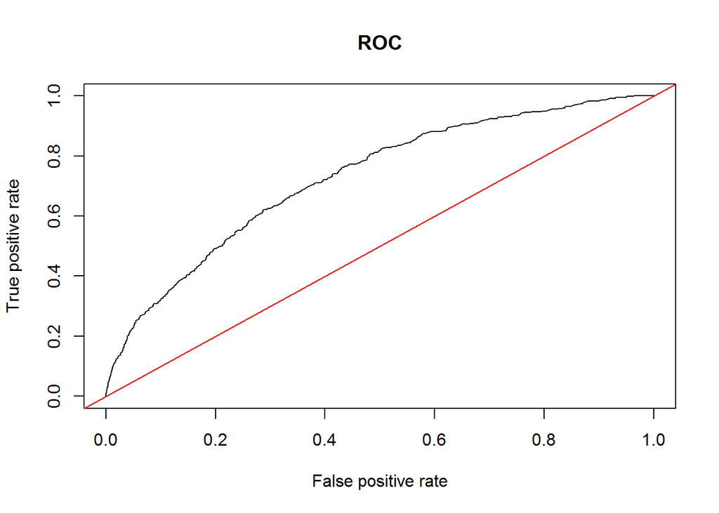

```r
    plot(prf, main = "ROC")
    abline(0,1, col = "red")
```

```r
    auc <- performance(pr, measure = "auc")
    auc <- auc@y.values[[1]]
    auc
```

```
## [1] 0.7277596
```

# Submission to Kaggle

submission_data <- data.frame(id = test$id, target = as.vector(pred))

fwrite(submission_data, “glm_model.csv”, row.names = FALSE)